# Bias and Fairness Analysis

Alexander McLain

2025-11-11

```r
knitr::opts_chunk$set(echo = TRUE, cache = TRUE, message = FALSE, warning = FALSE)
library(tidyverse)
library(tidymodels)
library(caret)
library(fairmodels)
# fairmodels uses DALEX explainers internally
# use DALEX::explain() to wrap fitted models
library(DALEX)
library(pROC)
library(kableExtra)
kbl2 <- function(x, ...) kable(x, align = "lrrrrrr", ...) %>% kable_styling(full_width = FALSE)
set.seed(2025)
```

# 1. Load and Prepare Data

```r
df <- read_csv("framingham.csv") %>%
  rename(sex = male)

# Outcome: TenYearCHD (binary)
# Predictors: age, sex, education, cigsPerDay, BPMeds, totChol, sysBP, glucose, etc.
glimpse(df)
```

```
## Rows: 4,240
## Columns: 16
## $ sex             <dbl> 1, 0, 1, 0, 0, 0, 0, 0, 1, 1, 0, 0, 1, 0, 0, 0, 1, 0, …
## $ age             <dbl> 39, 46, 48, 61, 46, 43, 63, 45, 52, 43, 50, 43, 46, 41…
## $ education       <dbl> 4, 2, 1, 3, 3, 2, 1, 2, 1, 1, 1, 2, 1, 3, 2, 2, 3, 2, …
## $ currentSmoker   <dbl> 0, 0, 1, 1, 1, 0, 0, 1, 0, 1, 0, 0, 1, 0, 1, 1, 1, 1, …
## $ cigsPerDay      <dbl> 0, 0, 20, 30, 23, 0, 0, 20, 0, 30, 0, 0, 15, 0, 9, 20,…
## $ BPMeds          <dbl> 0, 0, 0, 0, 0, 0, 0, 0, 0, 0, 0, 0, 0, 1, 0, 0, 0, 0, …
## $ prevalentStroke <dbl> 0, 0, 0, 0, 0, 0, 0, 0, 0, 0, 0, 0, 0, 0, 0, 0, 0, 0, …
## $ prevalentHyp    <dbl> 0, 0, 0, 1, 0, 1, 0, 0, 1, 1, 0, 0, 1, 1, 0, 1, 1, 0, …
## $ diabetes        <dbl> 0, 0, 0, 0, 0, 0, 0, 0, 0, 0, 0, 0, 0, 0, 0, 0, 0, 0, …
## $ totChol         <dbl> 195, 250, 245, 225, 285, 228, 205, 313, 260, 225, 254,…
## $ sysBP           <dbl> 106.0, 121.0, 127.5, 150.0, 130.0, 180.0, 138.0, 100.0…
## $ diaBP           <dbl> 70.0, 81.0, 80.0, 95.0, 84.0, 110.0, 71.0, 71.0, 89.0,…
## $ BMI             <dbl> 26.97, 28.73, 25.34, 28.58, 23.10, 30.30, 33.11, 21.68…
## $ heartRate       <dbl> 80, 95, 75, 65, 85, 77, 60, 79, 76, 93, 75, 72, 98, 65…
## $ glucose         <dbl> 77, 76, 70, 103, 85, 99, 85, 78, 79, 88, 76, 61, 64, 8…
## $ TenYearCHD      <dbl> 0, 0, 0, 1, 0, 0, 1, 0, 0, 0, 0, 0, 0, 0, 0, 1, 0, 1, …
```

The dataset includes demographic and cardiovascular risk factors for predicting 10-year coronary heart disease (CHD) risk.

We’ll examine whether a simple model’s predictions are **equally accurate** and **equally calibrated** across demographic groups.

# 2. Data Cleaning

```r
df <- df %>%
  drop_na(TenYearCHD, age, sex, education, cigsPerDay, totChol, sysBP, glucose, BPMeds) %>%
  mutate(
    TenYearCHD = factor(TenYearCHD, labels = c("NoCHD", "CHD")),
    sex = factor(sex, labels = c("Male", "Female")),
    education = factor(education)
  )

table(df$sex)
```

```
##
##   Male Female
##   2044   1628
```

```r
table(df$TenYearCHD)
```

```
##
## NoCHD   CHD
##  3107   565
```

# 3. Fit a Predictive Model

We’ll use a **logistic regression** model for 10-year CHD risk.

```r
split <- initial_split(df, prop = 0.8, strata = TenYearCHD)
train <- training(split)
test  <- testing(split)

rec <- recipe(TenYearCHD ~ age + sex + education + cigsPerDay + totChol + sysBP + glucose + BPMeds, data = train) %>%
  step_normalize(all_numeric_predictors())

model <- logistic_reg() %>%
  set_engine("glm")

wf <- workflow() %>%
  add_model(model) %>%
  add_recipe(rec)

fit_glm <- fit(wf, data = train)

# Predictions
preds <- predict(fit_glm, new_data = test, type = "prob") %>%
  bind_cols(predict(fit_glm, new_data = test, type = "class")) %>%
  bind_cols(test %>% select(TenYearCHD, sex, education))

head(preds)
```

```
## # A tibble: 6 × 6
##   .pred_NoCHD .pred_CHD .pred_class TenYearCHD sex    education
##         <dbl>     <dbl> <fct>       <fct>      <fct>  <fct>
## 1       0.950    0.0497 NoCHD       NoCHD      Male   2
## 2       0.738    0.262  NoCHD       NoCHD      Female 1
## 3       0.957    0.0428 NoCHD       NoCHD      Male   2
## 4       0.935    0.0653 NoCHD       NoCHD      Female 4
## 5       0.519    0.481  NoCHD       NoCHD      Female 1
## 6       0.955    0.0453 NoCHD       NoCHD      Male   2
```

# 4. Evaluate Overall Model Performance

```r
metrics <- preds %>%
  summarize(
    AUC = roc_auc_vec(TenYearCHD, .pred_CHD, event_level = "second"),
    Accuracy = accuracy_vec(TenYearCHD, .pred_class),
    Sensitivity = sens_vec(TenYearCHD, .pred_class, event_level = "second"),
    Specificity = spec_vec(TenYearCHD, .pred_class, event_level = "second"),
    PPV = ppv_vec(TenYearCHD, .pred_class, event_level = "second"),
    NPV = npv_vec(TenYearCHD, .pred_class, event_level = "second")
  ) %>%
  mutate(sex = "Overall", .before = AUC)

metrics %>% kbl2(digits = 3)
```

| sex | AUC | Accuracy | Sensitivity | Specificity | PPV | NPV |
| --- | --- | --- | --- | --- | --- | --- |
| Overall | 0.732 | 0.853 | 0.124 | 0.986 | 0.609 | 0.861 |

```r
table(preds$.pred_class, preds$TenYearCHD)
```

```
##
##         NoCHD CHD
##   NoCHD   613  99
##   CHD       9  14
```

# 5. Fairness: Compare Performance Across Groups

We’ll examine model metrics (AUC, accuracy, sensitivity, specificity) by **sex** and **education**.

```r
group_metrics <- preds %>%
  group_by(sex) %>%
  summarize(
    AUC = roc_auc_vec(TenYearCHD, .pred_CHD, event_level = "second"),
    Accuracy = accuracy_vec(TenYearCHD, .pred_class),
    Sensitivity = sens_vec(TenYearCHD, .pred_class, event_level = "second"),
    Specificity = spec_vec(TenYearCHD, .pred_class, event_level = "second"),
    PPV = ppv_vec(TenYearCHD, .pred_class, event_level = "second"),
    NPV = npv_vec(TenYearCHD, .pred_class, event_level = "second")
  )

metrics %>% bind_rows(group_metrics) %>% kbl2(digits = 3)
```

| sex | AUC | Accuracy | Sensitivity | Specificity | PPV | NPV |
| --- | --- | --- | --- | --- | --- | --- |
| Overall | 0.732 | 0.853 | 0.124 | 0.986 | 0.609 | 0.861 |
| Male | 0.709 | 0.876 | 0.021 | 0.994 | 0.333 | 0.880 |
| Female | 0.735 | 0.826 | 0.200 | 0.975 | 0.650 | 0.838 |

Compute the same for education level:

```r
group_metrics_edu <- preds %>%
  group_by(education) %>%
  summarize(
    AUC = roc_auc_vec(TenYearCHD, .pred_CHD, event_level = "second"),
    Accuracy = accuracy_vec(TenYearCHD, .pred_class),
    Sensitivity = sens_vec(TenYearCHD, .pred_class, event_level = "second"),
    Specificity = spec_vec(TenYearCHD, .pred_class, event_level = "second")
  )

group_metrics_edu %>% kbl2(digits = 3)
```

| education | AUC | Accuracy | Sensitivity | Specificity |
| --- | --- | --- | --- | --- |
| 1 | 0.743 | 0.812 | 0.161 | 0.976 |
| 2 | 0.684 | 0.878 | 0.071 | 0.995 |
| 3 | 0.558 | 0.892 | 0.091 | 0.980 |
| 4 | 0.845 | 0.884 | 0.083 | 1.000 |

# 6. Fairness Metrics via `fairmodels`

We can use the `fairmodels` package to audit group-level fairness.

```r
# Extract plain model for fairmodels
glm_fit <- extract_fit_parsnip(fit_glm)$fit

# Prepare test data
prep_rec <- prep(rec)
test_baked <- bake(prep_rec, new_data = test, composition = "data.frame")

# Prepare explainer
# Convert factor outcome to numeric 0/1 for DALEX + fairmodels
y_num <- ifelse(test_baked$TenYearCHD == "CHD", 1, 0)

# Create explainer
expl <- DALEX::explain(
  model = glm_fit,
  data = select(test_baked, -TenYearCHD),
  y = y_num,   # <-- numeric target
  label = "Logistic Regression"
)
```

```
## Preparation of a new explainer is initiated
##   -> model label       :  Logistic Regression
##   -> data              :  735  rows  8  cols
##   -> target variable   :  735  values
##   -> predict function  :  yhat.glm  will be used (  default  )
##   -> predicted values  :  No value for predict function target column. (  default  )
##   -> model_info        :  package stats , ver. 4.5.1 , task classification (  default  )
##   -> predicted values  :  numerical, min =  0.01597452 , mean =  0.1584938 , max =  0.9390141
##   -> residual function :  difference between y and yhat (  default  )
##   -> residuals         :  numerical, min =  -0.6865644 , mean =  -0.004752262 , max =  0.9785384
##   A new explainer has been created!
```

```r
# Bias audit: protected variable = sex
fobject <- fairness_check(expl, protected = test$sex, privileged = "Male")
```

```
## Creating fairness classification object
## -> Privileged subgroup       : character ( Ok  )
## -> Protected variable        : factor ( Ok  )
## -> Cutoff values for explainers  : 0.5 ( for all subgroups )
## -> Fairness objects      : 0 objects
## -> Checking explainers       : 1 in total (  compatible  )
## -> Metric calculation        : 13/13 metrics calculated for all models
##  Fairness object created succesfully
```

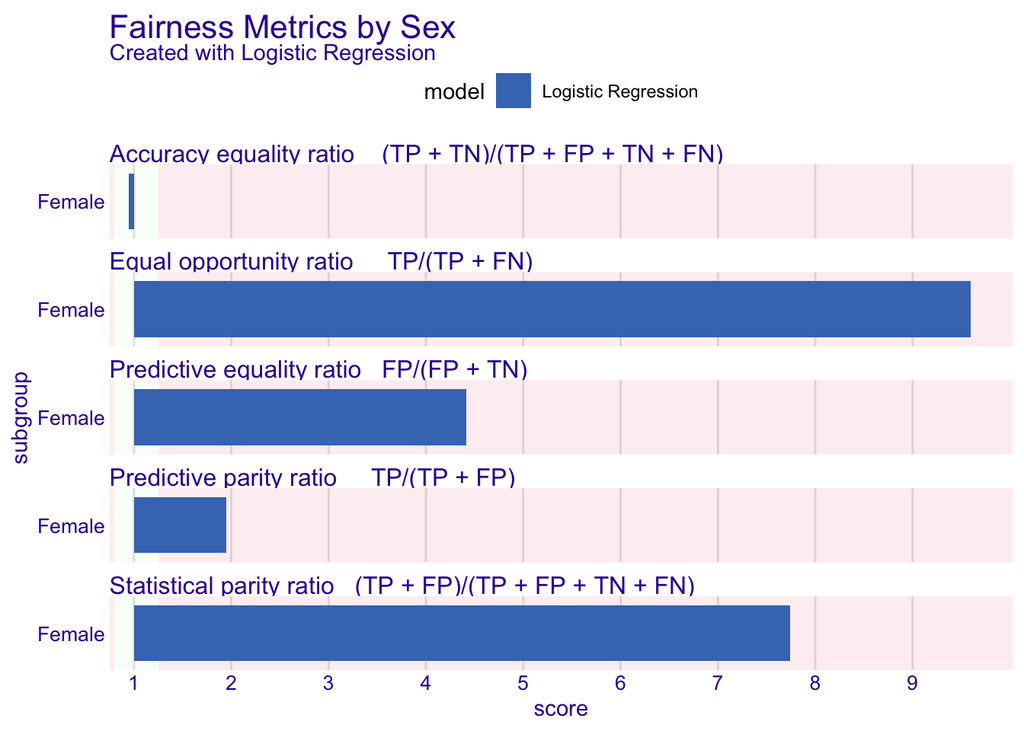

```r
# Thie creates a Fairness Object that compares model performance across subgroups of
# your protected variable. Here, i'm using sex = 'Male' to highlight how it looks
# when there is not equality across the groups.

plot(fobject) + ggtitle("Fairness Metrics by Sex")
```

• A large score means there’s a large disparity between groups — i.e., potentially unfair.

So the bars measure the degree of inequality, not the performance itself.

```r
fair_mets <- data.frame(t(unlist(fobject$groups_data)))
names(fair_mets) <- sub("Logistic.Regression.","",names(fair_mets))

fair_mets_long <- fair_mets %>%
  pivot_longer(
    cols = everything(),
    names_to = c("Metric", "Sex"),
    names_sep = "\\."
  ) %>%
  pivot_wider(
    names_from = Sex,
    values_from = value
  ) %>%
  filter(Metric != "NEW_METRIC") %>%
  mutate(
    Diff = Male - Female,
    Prop_Diff = (Male - Female)/Male)

fair_mets_long %>% kbl2(digits = 3)
```

| Metric | Male | Female | Diff | Prop_Diff |
| --- | --- | --- | --- | --- |
| TPR | 0.021 | 0.200 | -0.179 | -8.600 |
| TNR | 0.994 | 0.975 | 0.020 | 0.020 |
| PPV | 0.333 | 0.650 | -0.317 | -0.950 |
| NPV | 0.880 | 0.838 | 0.043 | 0.048 |
| FNR | 0.979 | 0.800 | 0.179 | 0.183 |
| FPR | 0.006 | 0.025 | -0.020 | -3.416 |
| FDR | 0.667 | 0.350 | 0.317 | 0.475 |
| FOR | 0.120 | 0.162 | -0.043 | -0.355 |
| TS | 0.020 | 0.181 | -0.161 | -8.028 |
| STP | 0.008 | 0.059 | -0.051 | -6.745 |
| ACC | 0.876 | 0.826 | 0.049 | 0.056 |
| F1 | 0.039 | 0.306 | -0.267 | -6.800 |

# 7. Calibration by Group

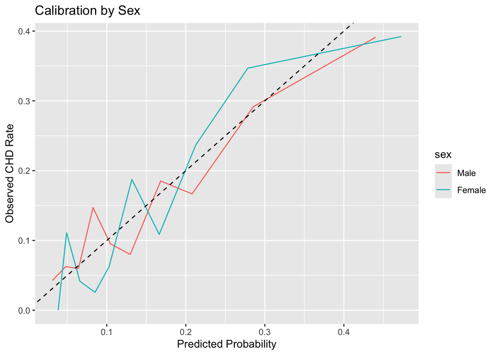

```r
preds %>%
  mutate(prob_bin = cut_number(.pred_CHD, 10)) %>%
  group_by(sex, prob_bin) %>%
  summarize(mean_prob = mean(.pred_CHD), observed = mean(TenYearCHD == "CHD")) %>%
  ggplot(aes(x = mean_prob, y = observed, color = sex)) +
  geom_line() +
  geom_abline(slope = 1, intercept = 0, linetype = 2) +
  labs(title = "Calibration by Sex", x = "Predicted Probability", y = "Observed CHD Rate")
```

# 8. Mitigation

## a. Group-specific decision thresholds

Even after training, you can still mitigate bias by choosing different cutoffs for different demographic groups. This is often done to equalize a fairness metric such as True Positive Rate (Equal Opportunity).

```r
# Compute ROC curves for each group
roc_male   <- roc(response = test$TenYearCHD[test$sex == "Male"],
                  predictor = preds$.pred_CHD[test$sex == "Male"],
                  levels = c("NoCHD", "CHD"))

roc_female <- roc(response = test$TenYearCHD[test$sex == "Female"],
                  predictor = preds$.pred_CHD[test$sex == "Female"],
                  levels = c("NoCHD", "CHD"))

# Choose thresholds that equalize TPRs (example: pick threshold with ~0.60 sensitivity)
# Helper function
approx_sens <- function(roc_obj, target) {
  df <- data.frame(sens = roc_obj$sensitivities, thresh = roc_obj$thresholds)
  approx(x = df$sens, y = df$thresh, xout = target, ties = mean)$y
}

th_male   <- approx_sens(roc_male, 0.60)
th_female <- approx_sens(roc_female, 0.60)
th_male; th_female
```

```
## [1] 0.1152831
```

```
## [1] 0.2269775
```

```r
# # Choose thresholds that maximize the sensitivity + specificity − 1
# th_male   <- coords(roc_male, "best", ret = "threshold", best.method = "youden")
# th_female <- coords(roc_female, "best", ret = "threshold", best.method = "youden")
#
# # These are the thresholds for the probabilities.
# th_male; th_female
```

Apply sex-specific cutoffs

```r
preds_grp <- preds %>%
  mutate(
    .pred_class_adj = case_when(
      sex == "Male"   & .pred_CHD >= th_male  ~ "CHD",
      sex == "Female" & .pred_CHD >= th_female ~ "CHD",
      TRUE ~ "NoCHD"
    )
  ) %>%
  mutate(
    .pred_class_adj = factor(.pred_class_adj, levels = c("NoCHD", "CHD"))
  )

# Compare fairness metrics after adjustment
Thres_res <- preds_grp %>%
  summarize(
    AUC = roc_auc_vec(TenYearCHD, .pred_CHD, event_level = "second"),
    Accuracy = accuracy_vec(TenYearCHD, .pred_class_adj),
    Sensitivity = sens_vec(TenYearCHD, .pred_class_adj, event_level = "second"),
    Specificity = spec_vec(TenYearCHD, .pred_class_adj, event_level = "second"),
    PPV = ppv_vec(TenYearCHD, .pred_class_adj, event_level = "second"),
    NPV = npv_vec(TenYearCHD, .pred_class_adj, event_level = "second")
  ) %>%
  mutate(sex = "Overall", .before = AUC)  %>%
  bind_rows(preds_grp %>%
  group_by(sex) %>%
  summarize(
    AUC = roc_auc_vec(TenYearCHD, .pred_CHD, event_level = "second"),
    Accuracy = accuracy_vec(TenYearCHD, .pred_class_adj),
    Sensitivity = sens_vec(TenYearCHD, .pred_class_adj, event_level = "second"),
    Specificity = spec_vec(TenYearCHD, .pred_class_adj, event_level = "second"),
    PPV = ppv_vec(TenYearCHD, .pred_class_adj, event_level = "second"),
    NPV = npv_vec(TenYearCHD, .pred_class_adj, event_level = "second")
  ) )%>%
  mutate(method = "Thresholds", .before = sex)
Original_res <- metrics %>% bind_rows(group_metrics) %>%
  mutate(method = "Original", .before = sex)
Original_res %>% bind_rows(Thres_res) %>%
  arrange(sex) %>% kbl2(digits = 3)
```

| method | sex | AUC | Accuracy | Sensitivity | Specificity | PPV | NPV |
| --- | --- | --- | --- | --- | --- | --- | --- |
| Original | Female | 0.735 | 0.826 | 0.200 | 0.975 | 0.650 | 0.838 |
| Thresholds | Female | 0.735 | 0.718 | 0.600 | 0.745 | 0.358 | 0.887 |
| Original | Male | 0.709 | 0.876 | 0.021 | 0.994 | 0.333 | 0.880 |
| Thresholds | Male | 0.709 | 0.686 | 0.583 | 0.700 | 0.212 | 0.924 |
| Original | Overall | 0.732 | 0.853 | 0.124 | 0.986 | 0.609 | 0.861 |
| Thresholds | Overall | 0.732 | 0.701 | 0.593 | 0.720 | 0.278 | 0.907 |

## b. Weighting

### Weighting by Sex

A simple fairness intervention is to reweight the training data so that both sexes contribute equally.

```r
# Compute weights inversely proportional to group frequency
train <- train %>%
  mutate(weight = 1 / (table(sex)[sex] / nrow(train)))

# Refit weighted logistic regression
fit_weighted <- glm(TenYearCHD ~ age + sex + education + cigsPerDay + totChol + sysBP + glucose + BPMeds,
                    data = train, family = binomial, weights = weight)

summary(fit_weighted)$coefficients %>% kbl2(digits = 3)
```

|  | Estimate | Std. Error | z value | Pr(>&#124;z&#124;) |
| --- | --- | --- | --- | --- |
| (Intercept) | -8.895 | 0.394 | -22.574 | 0.000 |
| age | 0.065 | 0.005 | 12.759 | 0.000 |
| sexFemale | 0.547 | 0.085 | 6.461 | 0.000 |
| education2 | -0.180 | 0.096 | -1.876 | 0.061 |
| education3 | -0.129 | 0.115 | -1.126 | 0.260 |
| education4 | -0.045 | 0.126 | -0.355 | 0.722 |
| cigsPerDay | 0.019 | 0.003 | 5.995 | 0.000 |
| totChol | 0.001 | 0.001 | 1.286 | 0.198 |
| sysBP | 0.019 | 0.002 | 10.388 | 0.000 |
| glucose | 0.008 | 0.001 | 5.459 | 0.000 |
| BPMeds | 0.158 | 0.184 | 0.856 | 0.392 |

```r
summary(glm_fit)$coefficients %>% kbl2(digits = 3)
```

|  | Estimate | Std. Error | z value | Pr(>&#124;z&#124;) |
| --- | --- | --- | --- | --- |
| (Intercept) | -2.119 | 0.110 | -19.281 | 0.000 |
| age | 0.559 | 0.063 | 8.896 | 0.000 |
| sexFemale | 0.535 | 0.120 | 4.471 | 0.000 |
| education2 | -0.206 | 0.137 | -1.503 | 0.133 |
| education3 | -0.143 | 0.163 | -0.881 | 0.378 |
| education4 | -0.063 | 0.183 | -0.343 | 0.732 |
| cigsPerDay | 0.233 | 0.055 | 4.212 | 0.000 |
| totChol | 0.043 | 0.056 | 0.777 | 0.437 |
| sysBP | 0.394 | 0.055 | 7.117 | 0.000 |
| glucose | 0.176 | 0.046 | 3.812 | 0.000 |
| BPMeds | 0.030 | 0.045 | 0.673 | 0.501 |

Re-evaluate bias after reweighting (as before):

```r
pred_weighted <- predict(fit_weighted, newdata = test, type = "response")
test$pred_weighted <- pred_weighted

test %>%
  mutate(.pred_class = if_else(pred_weighted > 0.5, "CHD", "NoCHD")) %>%
  mutate(.pred_class = factor(.pred_class, levels = c("NoCHD", "CHD"))) %>%
  group_by(sex) %>%
  summarize(
    AUC = roc_auc_vec(TenYearCHD, pred_weighted, event_level = "second"),
    Accuracy = accuracy_vec(TenYearCHD, .pred_class),
    Sensitivity = sens_vec(TenYearCHD, .pred_class, event_level = "second"),
    Specificity = spec_vec(TenYearCHD, .pred_class, event_level = "second")
  ) %>% kbl2(digits = 3)
```

| sex | AUC | Accuracy | Sensitivity | Specificity |
| --- | --- | --- | --- | --- |
| Male | 0.709 | 0.878 | 0.042 | 0.994 |
| Female | 0.735 | 0.826 | 0.200 | 0.975 |

Overall, this is not that effective. This is not surprising because there is not a big imbalance between male and female in the dataset (in fact, there are more males).

```r
table(train$sex)
```

```
##
##   Male Female
##   1649   1288
```

This points to using different cutoffs as being the better choice.

### Weighting by Outcome

There is a large imbalance in the outcome. Let’s try weighting to account for this imbalance.

```r
# Compute weights inversely proportional to group frequency
train <- train %>%
  mutate(weight_outcome = 1 / (table(TenYearCHD)[TenYearCHD] / nrow(train)))

# Refit weighted logistic regression
fit_weighted_out <- glm(TenYearCHD ~ age + sex + education + cigsPerDay + totChol + sysBP + glucose + BPMeds,
                    data = train, family = binomial, weights = weight_outcome)

summary(fit_weighted_out)$coefficients %>% kbl2(digits = 3)
```

|  | Estimate | Std. Error | z value | Pr(>&#124;z&#124;) |
| --- | --- | --- | --- | --- |
| (Intercept) | -7.009 | 0.287 | -24.437 | 0.000 |
| age | 0.066 | 0.004 | 17.074 | 0.000 |
| sexFemale | 0.506 | 0.062 | 8.211 | 0.000 |
| education2 | -0.238 | 0.071 | -3.338 | 0.001 |
| education3 | -0.230 | 0.085 | -2.709 | 0.007 |
| education4 | -0.161 | 0.097 | -1.670 | 0.095 |
| cigsPerDay | 0.021 | 0.003 | 8.099 | 0.000 |
| totChol | 0.001 | 0.001 | 1.554 | 0.120 |
| sysBP | 0.018 | 0.001 | 12.718 | 0.000 |
| glucose | 0.007 | 0.001 | 5.712 | 0.000 |
| BPMeds | 0.218 | 0.156 | 1.402 | 0.161 |

```r
summary(glm_fit)$coefficients %>% kbl2(digits = 3)
```

|  | Estimate | Std. Error | z value | Pr(>&#124;z&#124;) |
| --- | --- | --- | --- | --- |
| (Intercept) | -2.119 | 0.110 | -19.281 | 0.000 |
| age | 0.559 | 0.063 | 8.896 | 0.000 |
| sexFemale | 0.535 | 0.120 | 4.471 | 0.000 |
| education2 | -0.206 | 0.137 | -1.503 | 0.133 |
| education3 | -0.143 | 0.163 | -0.881 | 0.378 |
| education4 | -0.063 | 0.183 | -0.343 | 0.732 |
| cigsPerDay | 0.233 | 0.055 | 4.212 | 0.000 |
| totChol | 0.043 | 0.056 | 0.777 | 0.437 |
| sysBP | 0.394 | 0.055 | 7.117 | 0.000 |
| glucose | 0.176 | 0.046 | 3.812 | 0.000 |
| BPMeds | 0.030 | 0.045 | 0.673 | 0.501 |

Re-evaluate bias after reweighting (as before):

```r
pred_weighted_out <- predict(fit_weighted_out, newdata = test, type = "response")
test$pred_weighted_out <- pred_weighted_out


weight_res <- test %>%
  mutate(.pred_class = if_else(pred_weighted_out > 0.5, "CHD", "NoCHD")) %>%
  mutate(.pred_class = factor(.pred_class, levels = c("NoCHD", "CHD"))) %>%
  summarize(
    AUC = roc_auc_vec(TenYearCHD, pred_weighted_out, event_level = "second"),
    Accuracy = accuracy_vec(TenYearCHD, .pred_class),
    Sensitivity = sens_vec(TenYearCHD, .pred_class, event_level = "second"),
    Specificity = spec_vec(TenYearCHD, .pred_class, event_level = "second"),
    PPV = ppv_vec(TenYearCHD, .pred_class, event_level = "second"),
    NPV = npv_vec(TenYearCHD, .pred_class, event_level = "second")
  ) %>%
  mutate(sex = "Overall", .before = AUC) %>%
  bind_rows(
    test %>%
  mutate(.pred_class = if_else(pred_weighted_out > 0.5, "CHD", "NoCHD")) %>%
  mutate(.pred_class = factor(.pred_class, levels = c("NoCHD", "CHD"))) %>%
  group_by(sex) %>%
  summarize(
    AUC = roc_auc_vec(TenYearCHD, pred_weighted_out, event_level = "second"),
    Accuracy = accuracy_vec(TenYearCHD, .pred_class),
    Sensitivity = sens_vec(TenYearCHD, .pred_class, event_level = "second"),
    Specificity = spec_vec(TenYearCHD, .pred_class, event_level = "second"),
    PPV = ppv_vec(TenYearCHD, .pred_class, event_level = "second"),
    NPV = npv_vec(TenYearCHD, .pred_class, event_level = "second")
  )) %>% mutate(method = "Weighting", .before = sex)
Original_res %>% bind_rows(Thres_res) %>%
  bind_rows(weight_res) %>% kbl2(digits = 3)
```

| method | sex | AUC | Accuracy | Sensitivity | Specificity | PPV | NPV |
| --- | --- | --- | --- | --- | --- | --- | --- |
| Original | Overall | 0.732 | 0.853 | 0.124 | 0.986 | 0.609 | 0.861 |
| Original | Male | 0.709 | 0.876 | 0.021 | 0.994 | 0.333 | 0.880 |
| Original | Female | 0.735 | 0.826 | 0.200 | 0.975 | 0.650 | 0.838 |
| Thresholds | Overall | 0.732 | 0.701 | 0.593 | 0.720 | 0.278 | 0.907 |
| Thresholds | Male | 0.709 | 0.686 | 0.583 | 0.700 | 0.212 | 0.924 |
| Thresholds | Female | 0.735 | 0.718 | 0.600 | 0.745 | 0.358 | 0.887 |
| Weighting | Overall | 0.733 | 0.669 | 0.690 | 0.666 | 0.273 | 0.922 |
| Weighting | Male | 0.711 | 0.739 | 0.562 | 0.764 | 0.248 | 0.927 |
| Weighting | Female | 0.736 | 0.588 | 0.785 | 0.542 | 0.288 | 0.914 |

## c. SMOTE (Synthetic Minority Oversampling Technique)

The Framingham data (or any CHD dataset) tends to have far fewer “CHD” cases (positives) than “NoCHD” (negatives). This imbalance can cause the model to favor the majority class — often disadvantaging underrepresented subgroups (e.g., females).

```r
library(themis)  # for SMOTE

# Recipe with SMOTE
rec_smote <- recipe(TenYearCHD ~ age + sex + education + cigsPerDay + totChol + sysBP + glucose + BPMeds, data = train) %>%
  step_dummy(all_nominal_predictors()) %>%        # convert factors to dummies
  step_normalize(all_numeric_predictors()) %>%
  step_smote(TenYearCHD, over_ratio = 1)          # oversample minority class via SMOTE

# Fit the same logistic model
wf_smote <- workflow() %>%
  add_recipe(rec_smote) %>%
  add_model(logistic_reg() %>% set_engine("glm"))

fit_smote <- fit(wf_smote, data = train)

# Check new class balance
train_balanced <- bake(prep(rec_smote), new_data = NULL)
table(train_balanced$TenYearCHD)
```

```
##
## NoCHD   CHD
##  2485  2485
```

```r
# Predictions
preds_smote <- predict(fit_smote, new_data = test, type = "prob") %>%
  bind_cols(predict(fit_smote, new_data = test, type = "class")) %>%
  bind_cols(test %>% select(TenYearCHD, sex, education))
```

What’s happening:

• `step_smote()` synthetically generates new minority-class examples by interpolating between nearest neighbors in feature space.

• `over_ratio = 1` roughly equalizes positives and negatives.

• This step can reduce overall bias in model learning before you even consider fairness metrics.

Let’s evaluate the overall model performance and compare to the previous approaches:

```r
group_metrics_smote <- preds_smote %>%
  group_by(sex) %>%
  summarize(
    AUC = roc_auc_vec(TenYearCHD, .pred_CHD, event_level = "second"),
    Accuracy = accuracy_vec(TenYearCHD, .pred_class),
    Sensitivity = sens_vec(TenYearCHD, .pred_class, event_level = "second"),
    Specificity = spec_vec(TenYearCHD, .pred_class, event_level = "second")
  )

smote_res <- preds_smote %>%
  summarize(
    AUC = roc_auc_vec(TenYearCHD, .pred_CHD, event_level = "second"),
    Accuracy = accuracy_vec(TenYearCHD, .pred_class),
    Sensitivity = sens_vec(TenYearCHD, .pred_class, event_level = "second"),
    Specificity = spec_vec(TenYearCHD, .pred_class, event_level = "second"),
    PPV = ppv_vec(TenYearCHD, .pred_class, event_level = "second"),
    NPV = npv_vec(TenYearCHD, .pred_class, event_level = "second")
  ) %>%
  mutate(sex = "Overall", .before = AUC)  %>%
  bind_rows(preds_smote %>%
  group_by(sex) %>%
  summarize(
    AUC = roc_auc_vec(TenYearCHD, .pred_CHD, event_level = "second"),
    Accuracy = accuracy_vec(TenYearCHD, .pred_class),
    Sensitivity = sens_vec(TenYearCHD, .pred_class, event_level = "second"),
    Specificity = spec_vec(TenYearCHD, .pred_class, event_level = "second"),
    PPV = ppv_vec(TenYearCHD, .pred_class, event_level = "second"),
    NPV = npv_vec(TenYearCHD, .pred_class, event_level = "second")
  ) )%>%
  mutate(method = "SMOTE", .before = sex)


Original_res %>% bind_rows(Thres_res) %>%
  bind_rows(weight_res) %>%
  bind_rows(smote_res) %>%  kbl2(digits = 3)
```

| method | sex | AUC | Accuracy | Sensitivity | Specificity | PPV | NPV |
| --- | --- | --- | --- | --- | --- | --- | --- |
| Original | Overall | 0.732 | 0.853 | 0.124 | 0.986 | 0.609 | 0.861 |
| Original | Male | 0.709 | 0.876 | 0.021 | 0.994 | 0.333 | 0.880 |
| Original | Female | 0.735 | 0.826 | 0.200 | 0.975 | 0.650 | 0.838 |
| Thresholds | Overall | 0.732 | 0.701 | 0.593 | 0.720 | 0.278 | 0.907 |
| Thresholds | Male | 0.709 | 0.686 | 0.583 | 0.700 | 0.212 | 0.924 |
| Thresholds | Female | 0.735 | 0.718 | 0.600 | 0.745 | 0.358 | 0.887 |
| Weighting | Overall | 0.733 | 0.669 | 0.690 | 0.666 | 0.273 | 0.922 |
| Weighting | Male | 0.711 | 0.739 | 0.562 | 0.764 | 0.248 | 0.927 |
| Weighting | Female | 0.736 | 0.588 | 0.785 | 0.542 | 0.288 | 0.914 |
| SMOTE | Overall | 0.734 | 0.672 | 0.681 | 0.670 | 0.273 | 0.921 |
| SMOTE | Male | 0.713 | 0.739 | 0.562 | 0.764 | 0.248 | 0.927 |
| SMOTE | Female | 0.735 | 0.594 | 0.769 | 0.553 | 0.289 | 0.910 |

In general, SMOTE will give better prediction metrics than weighting (even though we don’t see that here). Otherwise, weighting is preferred since you can still get inferences about the coefficients (i.e., p-values and CI’s). For models where inferences about coefficients are not of interest (e.g., random forest, SVM, NNs), SMOTE is more popular.

**SMOTE summary:**

- Used when the *outcome classes* are highly imbalanced (e.g., few CHD cases).
- Generates synthetic minority samples between nearest neighbors.
- Balances training data to reduce bias toward the majority outcome.
- The focus after SMOTE is prediction, **not inference. Standard errors are underestimated with SMOTE and p-values are biased.** If inference is your goal than weighting is a better option.
- **Limitations:** may distort feature distributions; does not address demographic bias;

# 9. Discussion

- **Bias detection:** unequal AUCs, sensitivities, or calibration across groups indicate potential bias.
- **Bias mitigation:** reweighting or fairness-constrained optimization can reduce disparities.
- **Trade-off:** improvements in fairness may slightly reduce overall accuracy.
- **Public-health relevance:** equitable performance is crucial when models guide screening or resource allocation.

# References

- Hardt, M., Price, E., & Srebro, N. (2016). *Equality of Opportunity in Supervised Learning*.
- Kamiran, F., & Calders, T. (2012). *Data Preprocessing Techniques for Classification without Discrimination*.
- R Core Team (2025). *mlbench package documentation*.